# podsumowanie

## Wprowadzenie

Celem niniejszego dokumentu jest porównanie wyników zwaranych przez algorytm projektujący graf na przestrzeń d-wymiarową. Wyniki algorytmu są prezentowane na wykresie punktowym - w przypadku wartości $d > 2$ wynik algorytmu jest dodatkowo rzutowany na przestrzeń 2-wymiarową za pomocą gotowego algorytmu PCA. Dla porównania wyniki algorytmu używającego funkcję scipy.optimize.minimize są zestawione z algorytmem zwracającym podobne wyniki, ale wyznaczający je przy pomocy wartości i wektorów własnych.

```python
import main
np.random.seed(44)
```

## Porównanie algorytmów

```
Created a cycle graph, with 5 nodes
```

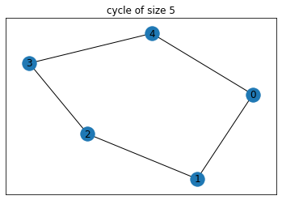

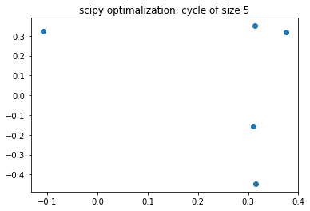

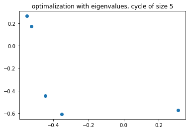

```python
# examples
# two dimensional projection

n = 5
graph = Graph()
graph.cycle_graph(n)
graph.show_results("cycle")
```

```
Created a cycle graph, with 5 nodes
```

```
<class 'networkx.utils.decorators.argmap'> compilation 12:4: FutureWarning: laplacian_matrix will return a scipy.sparse array instead of a matrix in Networkx 3.0.
```

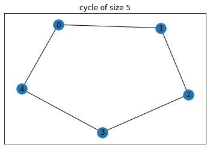

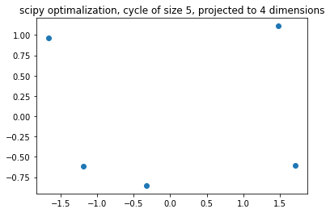

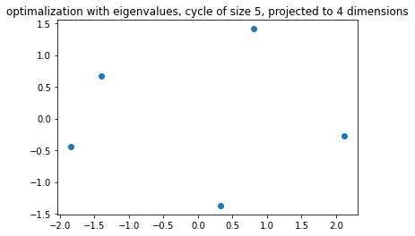

```python
n = 5
graph = Graph()
graph.cycle_graph(n)
graph.show_results("cycle", 4)
```

Jak się okazuje, w tym przypadku algorytm dla d=4 poradził sobie znacznie lepiej niż wersja z d=2 - w obu przypadkach (algorytmu z scipy.optimize.minimize oraz za pomocą liczenia wartości własnych)

```
Created a cycle graph, with 10 nodes
```

```
<class 'networkx.utils.decorators.argmap'> compilation 12:4: FutureWarning: laplacian_matrix will return a scipy.sparse array instead of a matrix in Networkx 3.0.
```

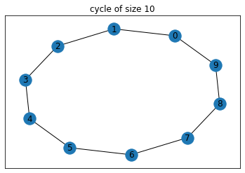

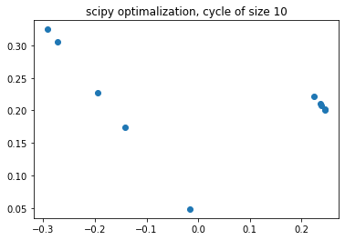

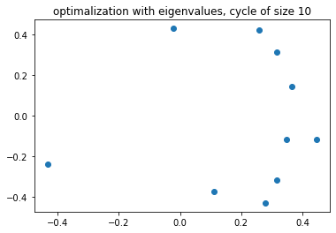

```python
n = 10
graph.cycle_graph(n)
graph.show_results("cycle")
```

```
Created a cycle graph, with 10 nodes
```

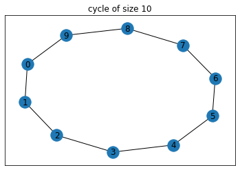

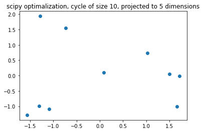

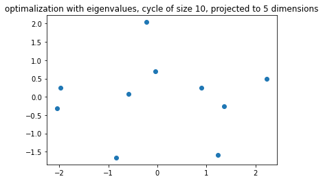

```python
n = 10
graph = Graph()
graph.cycle_graph(n)
graph.show_results("cycle", 5)
```

```
Created a cycle graph, with 10 nodes
```

```
<class 'networkx.utils.decorators.argmap'> compilation 12:4: FutureWarning: laplacian_matrix will return a scipy.sparse array instead of a matrix in Networkx 3.0.
```

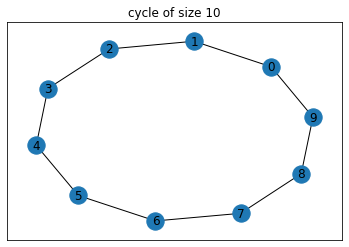

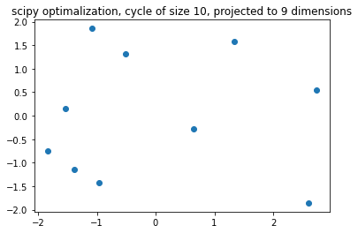

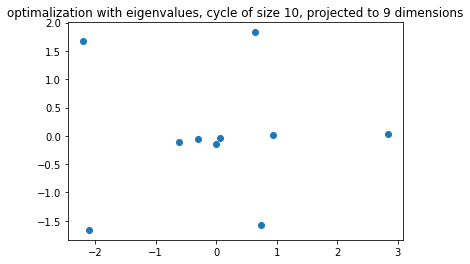

```python
n = 10
graph = Graph()
graph.cycle_graph(n)
graph.show_results("cycle", 9)
```

W tym przypadku algorytm z d=2 poradził sobie moim zdaniem trochę lepiej niż dla d=5. Mimo długiego czasu wykonywania obliczeń, najlepiej sprawdził się jednak algorytm dla d=9 - mimo drobnych zakłóceń, reprezentacja grafu najbardziej przypomina cykl.

Jeżeli chodzi o optymalizacje przy użyciu wartości własnych najlepiej sprawdził się algorytm dla d=2.

```
Created a barbell graph, with 5 and 3 nodes
```

```
<class 'networkx.utils.decorators.argmap'> compilation 12:4: FutureWarning: laplacian_matrix will return a scipy.sparse array instead of a matrix in Networkx 3.0.
```

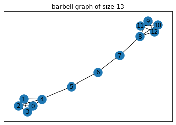

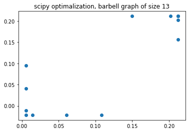

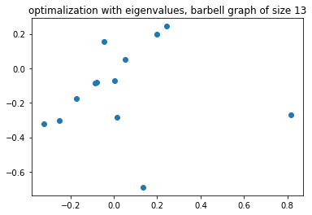

```python
graph.barbell_graph(5, 3)
graph.show_results("barbell graph")
```

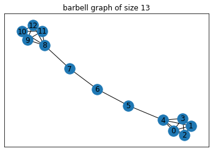

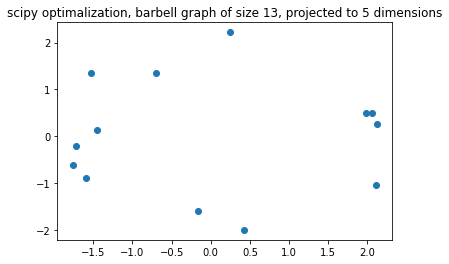

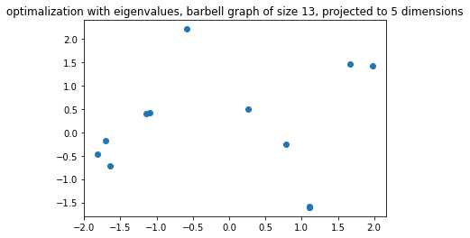

```python
graph.show_results("barbell graph", 5)
```

```
<class 'networkx.utils.decorators.argmap'> compilation 12:4: FutureWarning: laplacian_matrix will return a scipy.sparse array instead of a matrix in Networkx 3.0.
```

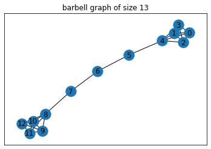

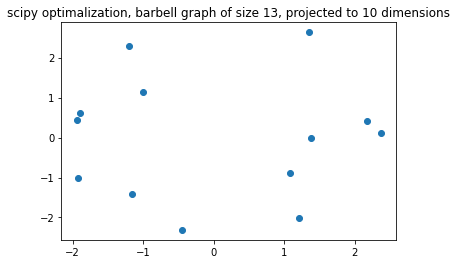

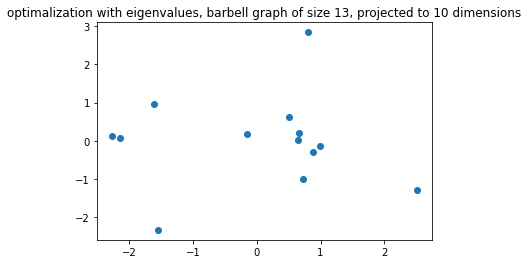

```python
graph.show_results("barbell graph", 10)
```

W przypadku grafu sztangowego, najlepiej sprawuje się algorytm dla d=2 - na wykresie łatwo zauważyć zgrupowane punktów w dwóch miejscach. Dla większych wartości d nie widać tak wyraźnie zgrupowania.